# Chapter 14 Collaborative Filtering

Satoshi Koiso

06/05/2022

This is an R Markdown document about Chapter 14 of [this book](https://www.shoeisha.co.jp/book/detail/9784798143446).

## 14.2 Algorithums

### Three Types of Algorithums

| Category | Overview | Methods |
| --- | --- | --- |
| Memory-based | Based on the similarities between users/items | User-based, Item-based |
| Model-based | Based on classification models with learning data, identify the patterns of purchase activities | Bayesian Network, Clustering, and Regression models |
| Hybrid | Between Memory-based and Model-based | - |

## 14.4 Recommenderlab

### Datatype

- realRatingMatrix: Numeric and non-binary rating
- binaryRatingMatrix: binary rating (0 or 1)

```r
data("MovieLense")
MovieLense
```

```
## 943 x 1664 rating matrix of class 'realRatingMatrix' with 99392 ratings.
```

```r
# convert into dataframe
head(as(MovieLense, "data.frame"))
```

```
##     user                                                 item rating
## 1      1                                     Toy Story (1995)      5
## 453    1                                     GoldenEye (1995)      3
## 584    1                                    Four Rooms (1995)      4
## 674    1                                    Get Shorty (1995)      3
## 883    1                                       Copycat (1995)      3
## 969    1 Shanghai Triad (Yao a yao yao dao waipo qiao) (1995)      5
```

```r
# convert into matrix
as(MovieLense, "matrix")[501:505, 1:5]
```

```
##     Toy Story (1995) GoldenEye (1995) Four Rooms (1995) Get Shorty (1995)
## 501               NA               NA                NA                NA
## 502               NA               NA                NA                NA
## 503                5               NA                NA                NA
## 504               NA               NA                NA                 4
## 505                3               NA                NA                NA
##     Copycat (1995)
## 501             NA
## 502             NA
## 503             NA
## 504              4
## 505             NA
```

### Visualize rating

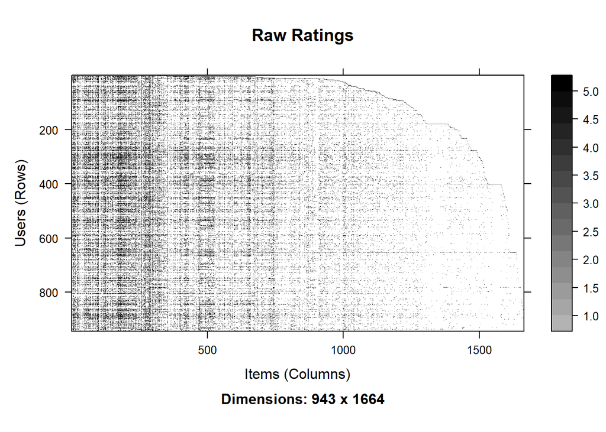

```r
image(MovieLense, main="Raw Ratings")
```

### Descriptive Statistics

```r
# Number of Rating by user
rowCounts(MovieLense)
```

[output not shown]

[output cut: 81 more lines]

```r
summary(rowCounts(MovieLense))
```

```
##    Min. 1st Qu.  Median    Mean 3rd Qu.    Max.
##    19.0    32.0    64.0   105.4   147.5   735.0
```

```r
# Ave. Rating Score by user
rowMeans(MovieLense)
```

[output not shown]

[output cut: 181 more lines]

[output not shown]

```r
summary(rowMeans(MovieLense))
```

```
##    Min. 1st Qu.  Median    Mean 3rd Qu.    Max.
##   1.497   3.325   3.619   3.588   3.871   4.870
```

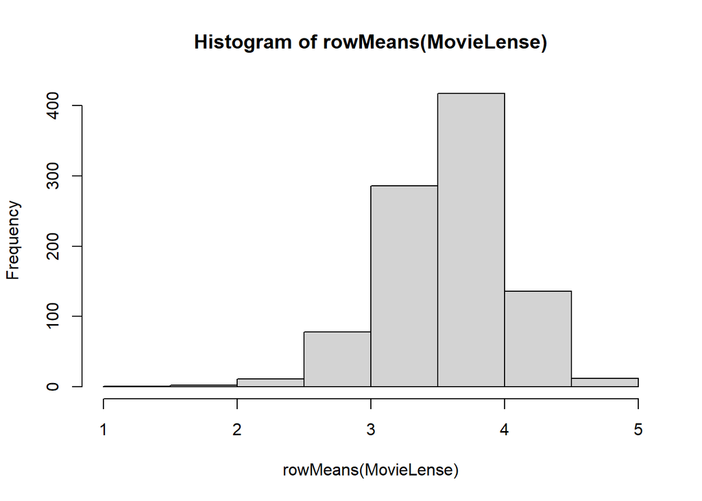

```r
hist(rowMeans(MovieLense))
```

We could say that there are biases among the users. Some tend to rate higher than others do. It is common to normalize the data in advance using `recommenderlab::normalize` - center: Subtract the average rate of the user from non-NA rate - Z-score: Divide the result of the above center by the standard deviation of the user

```r
rowMeans(normalize(MovieLense, method = "center"))
```

[output not shown]

[output cut: 323 more lines]

[output not shown]

```r
summary(rowMeans(normalize(MovieLense, method = "center")))
```

```
##       Min.    1st Qu.     Median       Mean    3rd Qu.       Max.
## -2.331e-15 -1.714e-16  0.000e+00  8.402e-18  1.700e-16  3.152e-15
```

### Apply Algorithms

Algorithms in `recommenderlab``

| Algorithm | Overview | realRatingMatrix | binaryRatingMatrix |
| --- | --- | --- | --- |
| RANDOM | Choose items at random and recommend them | Yes | Yes |
| POPULAR | Recommend popular items based on the number of buyers | Yes | Yes |
| UBCF | User-Based Collaborative Filtering | Yes | Yes |
| IBCF | Item-Based Collaborative Filtering | Yes | Yes |
| PCA | Principal Component Analysis | Yes | No |
| SVD | Singular Value Decomposition (for demention reduction) | Yes | No |
| AR | Recommend items based on association rule | No | Yes |

```r
# summary
# recommenderRegistry$get_entries(dataType='realRatingMatrix')
# recommenderRegistry$get_entries(dataType='binaryRatingMatrix')
```

## Create Recommender

Let’s do UBCF (User-Based Collaborative Filtering). 1. Create recommender based on trainging data 2. Predict recommendation: Create Top-N list and predict rading

### 1. Create Recommender

Use `Recommender`function. the 1st arg is training data of rating matrix and 2nd arg is method.

```r
# with the first 500 data
r <- Recommender(MovieLense[1:500], method ="UBCF")
```

### 2. Predict Recommendation

Use `predict` function. Do recommendation.

```r
# predict rating of #501-505 users
p <- predict(r, MovieLense[501:505], type = "ratings")

# display the predicted ratings of the first 5 movies
as(p, "matrix")[1:5,1:5]
```

```
##     Toy Story (1995) GoldenEye (1995) Four Rooms (1995) Get Shorty (1995)
## 501         2.572939         1.352838                NA          4.135544
## 502         3.076558         2.706401          3.020982          2.685635
## 503               NA               NA                NA          3.065153
## 504         4.136508               NA                NA                NA
## 505               NA               NA                NA                NA
##     Copycat (1995)
## 501       3.621530
## 502       2.876681
## 503             NA
## 504             NA
## 505             NA
```

For the movies the users already rated, **NA** is shown.

## Evaluate the algorithms

With RMSE, evaluate the algorithms 1. Create the evaluation criteria 2. Evaluate

### 1. Create the evaluation criteria

```r
# Split method
e <- evaluationScheme(MovieLense, method = "split", train = 0.9, given = 15)

# set 90% of data as training and 10% as test
# 15 items in the test data for prediction and the other for prediction error calculation
```

### 2. Evaluate

```r
# UBCF recommender with training data
r.ubcf <- Recommender(getData(e, "train"), method = "UBCF")
# IBCF recommender with training data
r.ibcf <- Recommender(getData(e, "train"), method = "IBCF")

# Predict with test data and UBCF recommender
p.ubcf <- predict(r.ubcf, getData(e, "known"), type = "ratings")
# Predict with test data and IBCF recommender
p.ibcf <- predict(r.ibcf, getData(e, "known"), type = "ratings")
```

Calculate accuracies of UBCF and IBCF

```r
e <- rbind(calcPredictionAccuracy(p.ubcf, getData(e,"unknown")),
           calcPredictionAccuracy(p.ibcf, getData(e,"unknown")))
rownames(e) <- c("UBCF","IBCF")
e
```

```
##          RMSE      MSE       MAE
## UBCF 1.183483 1.400632 0.9304304
## IBCF 1.151339 1.325581 0.8255814
```

IBCF has higher accuracy.

```r
help(package="recommenderlab")
```